# Enriched Camera Monitoring System

### With Computer Vision and Machine Learning

- **Student:** Adam Napora (18197892)
- **Supervisor:** Dr. Alessio Benavoli
- **Date:** 3rd September 2020

[figure not shown]

## Agenda

- Introduction, Research Questions / Contributions
- Methodology and Results:
  - Tools, Software Utilized
  - Data collection
  - Prediction of Counts per Hour
  - Two Methods for Anomaly Detection
- Limitations and Future Work
- Demo

## Introduction

- **Initial goal:** (2018) An object detection toy-project, for cat behaviour monitoring
- **Key milestone:** (2019, in Limerick), initial idea for thesis:

  > Can object detections be used to predict future events?
- **Ultimate idea:** (2020) Identify anomalies, which could trigger alerts

## Research Questions / Contributions

1. Assess the complexity in a reliable object detection pipeline
2. Given the dataset with object detections, can counts per hour be predicted?
3. Can Anomaly Detection algorithms help, to recognize unexpected patterns in the image data?

If the research is successful - the final product should be generalizable to other use cases (city planning, animal behaviour anomalies, traffic congestion, etc.).

Anyone can set up their own monitoring system (source code and diagrams pushed to Github).

## Methodology & Results

- Tools / Software Utilized
- Data Collection
- Prediction of Counts per Hour
- Two Methods for Anomaly Detection

## Tools / Software Utilized

- **Python3** - primary programming language
- **Jupyter Notebooks** - experiments, dissertation, slides
- **Python libraries**:
  - **Pandas, Numpy** - data processing and manipulation
  - **OpenCV** - Computer Vision
  - **Plotly** - Data visualization
  - **Pymc3, GPy** - Bayesian programming, Gaussian Process
  - **Sklearn, Keras** - Machine Learning, Deep Learning
  - **ImageZMQ** - Message Queue
  - others ...
- **VueJS** - JavaScript framework for modern and scalable UI's

## Data Collection

## Data Collection - Hardware

- Networking:
  - **Ethernet**
  - POE Switches
  - Static IP Addresses
- Devices:
  - Desktop PC (**GPU**)
  - Raspberry PI (+ Pi Camera)
- Challenges to Consider:
  - Environmental (sun, rain, humidity, wildlife)
  - Camera placement
  - Dealing with downtimes

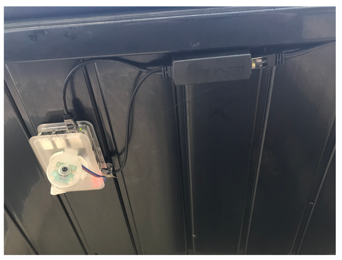

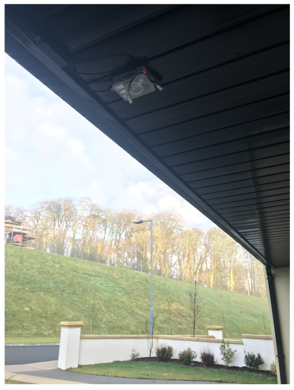

## Data Collection - System Diagram

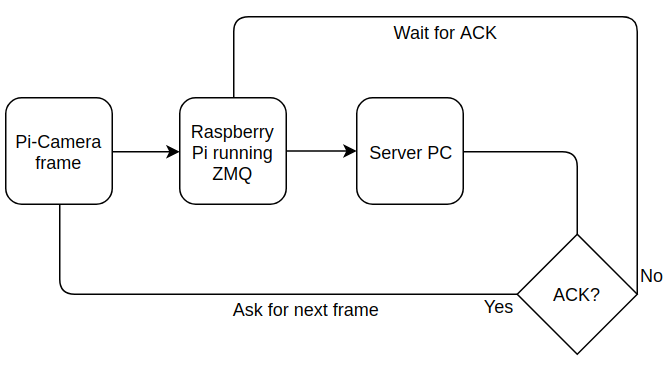

## Data Collection - Frame Processing

Data pipeline for each frame received by the Desktop (Server) PC:

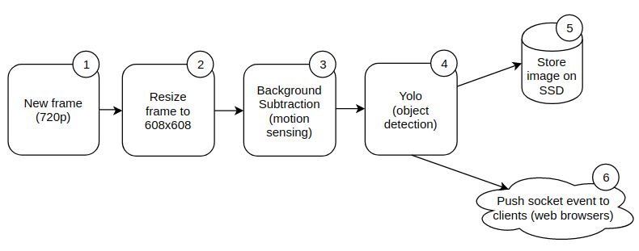

## Data Collection - Results

- 6 months of image data collection: 600K+ detections, 180 GB
- 3 days of downtime (power outages)
- File naming convention / object category distribution:

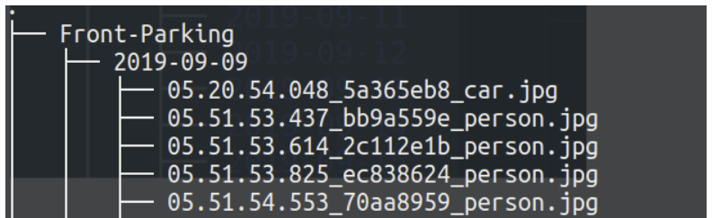

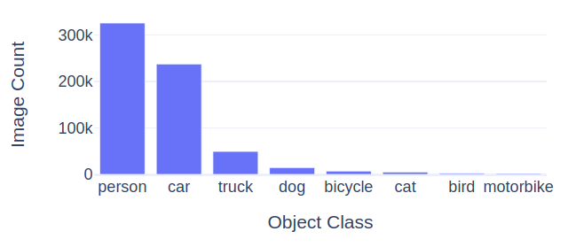

## Hourly Counts Prediction

## Hourly Counts Prediction - Goal / Data

- **Goal:** Ability to answer questions, like:
  - How many `People` will show between `7AM and 8AM`, on `Saturday`, given a `sunny` and `warm` day?
  - What is the probability to see a `Person` in the next `15` minutes?
- **Data:** Multivariate time series dataset for each object category. Steps to prepare:
  - Extract detections from images (Yolo, OpenCV)
  - Count **unique objects** in a time interval (Euclidean Distance)
  - Fetch weather forecast data (Dark Sky API)

## Hourly Counts Prediction - Model

- Train supervised Machine Learning model with **Poisson loss** (applicable to count data problems)
- Features: `uvIndex,hour,month,dayOfWeek,isWeekend,` `precipitation,temperature,humidity,windSpeed`
- Predict rates per hour ($\lambda$)
- Rates can be utilized to contruct probabilities for each count: $\{0,1,2, ... ,10\}$, with Possion probability mass function (pmf):

$$f(k;\lambda) = Pr(X=k) = \frac{\lambda^{k} e^{-\lambda}}{k!})$$

, where $\lambda>0$, expected value and variance are both equal to $\lambda$, $e$ is Euler's number ($e=2.718...$), and $k!$ is the factorial of count $k$.

## Prediction of Counts Per Hour - Results

- Dozens of tested algorithms. All had their benefits and drawbacks
- **Gaussian Process** and **Histogram-based Gradient Boosting Regressor** achieved the lowest error rates for *Person* prediction:

| Model | Mean Poisson Deviance | Mean Squared Error | Mean Absolute Error | R2 Score |
| --- | --- | --- | --- | --- |
| **Gaussian Process** | 1.21 | 2.35 | 0.86 | 0.33 |
| **Gradient Boost** | 1.25 | 2.47 | 0.87 | 0.36 |

- **Gaussian Process** allows to analyze and utilize uncertainty in the predictions
- **Gradient Boost** is more robust, when trained on various object categories (Person, Vehicle etc.)

## Anomaly Detection

## Anomaly Detection - Hourly threshold estimation

- **Problem Statement:** Find anomalies in object counts
- **Methodology:** Estimate a maximum hourly threshold via probabilistic programming (pymc3)

## Anomaly Detection - Hourly Thresholds Estimation - Results

- Probabilistic model:
  - Prior: Gamma distribution and Poisson likelihood
  - Estimated thresholds by hour:

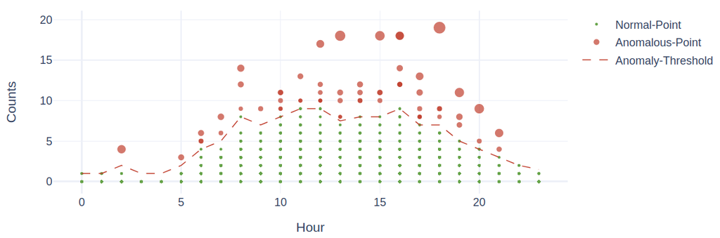

## Anomaly Detection - Raw Pixel Analysis

- **Problem Statement:** Find anomalies in raw image data
- **Methodology:** Use unsupervised Machine Leaning - Convolutional Auto-Encoder, to score images as *normal* or *anomalous*

## Anomaly Detection - Raw Pixel Analysis - Data

- **Dataset:** sampled $10K$ images, resized to $56 \times 56$
- **Preprocessing:** gray scale; blur; threshold; crop. Example original vs preprocessed image:

[figure not shown]

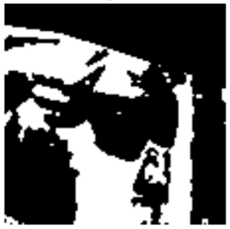

## Anomaly Detection - Raw Pixel Analysis - Deep Learning Model

- Convolutional Auto-encoder ($32$ and $64$ filters)
- Leaky ReLU Activation
- $16$-node Bottleneck Layer
- Optimizer: Adam
- Loss: Mean Squared Error

## Anomaly Detection - Raw Pixel Analysis - Evaluation

Classification of hand-labeled dataset with $30$ images (with $15$ anomalies):

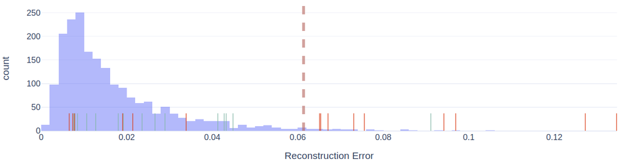

- Model optimized for *Recall*
- Plot shows $6$ anomalous images misclassified out of $15$ (Recall=$0.6$)

## Known System Limitations

- System has not yet been tested in another location
- Utilized camera type is basic (lack of night vision capability, or waterproof case)
- Limited forecast accuracy (stochastic process)

## Suggested Improvements / Future Work

- Develop a Minimum Viable Product, to identify incorrect assumptions, and potential weaknesses
- Incorporate **ethics** and privacy protection
- Deploy in another household
- And many other ...

## Demo

## Demo - Data Collection

[video not shown]

## Demo - Hourly Counts Prediction

[video not shown]